# A3: Incarceration

### Introduction

In this analysis, I will examine jail incarceration rates across different racial and gender groups to uncover patterns of inequality. This analysis will focus on racial disparities among Black, White, Native American, Asian American and Pacific Islander (AAPI), and Latinx populations. Additionally, we will analyze gender and age disparities, specifically comparing male adults, female adults, male juveniles, and female juveniles. To provide a localized perspective, we will also investigate jail rates for different races within Washington State. This analysis aims to quantify the extent of these disparities and provide evidence-based insights into systemic biases in the criminal justice system.

### The Dataset

The data was collected by the Vera Institute of Justice. The data was collected from two primary Bureau of Justice Statistics (BJS) data collections: the Census of Jails (COJ), which covers all jails and is conducted every five to eight years since 1970, and the Annual Survey of Jails (ASJ), which covers about one-third of jails-and includes nearly all of the largest jails-that has been conducted in non-census years since 1982. This project was funded by the Robert W. Wilson Charitable Trust.The data was collected to provide detailed insights into jail and prison populations at the county level across the United States. This level of detail is intended to help understand the variability in incarceration practices and outcomes among counties, providing a robust foundation for research and policy-making aimed at addressing mass incarceration. The number of observations (rows) in the Dataset about prison population per county/state and Dataset about jail population per county/state data are 153811, and Prison/jail population per 100,000 people (rate) per county/state starting at 1990 in Washington is 1131. The number of features (columns) in the Dataset about prison population per county/state and Dataset about jail population per county/state data is 33, the Dataset about prison population per county/state is 36, and Prison/jail population per 100,000 people (rate) per county/state starting at 1990 in Washington is 23. Working with incarceration data raises several ethical questions and issues of power. One major concern is the potential for data to reinforce negative stereotypes or biases against certain racial or demographic groups. There is also the risk of violating individuals’ privacy, even in aggregate data. The data has several potential limitations as there may be gaps or inconsistencies due to varying data collection methods over the years. The presence of numerous N/A values suggests incomplete data, which can lead to biased analyses or conclusions. Additionally, jail and prison data are not uniformly reported across all counties, leading to potential discrepancies. The aggregation of data at the county level may obscure significant variations within counties. Lastly, the evolving nature of incarceration practices and policies means that historical data might not fully reflect current realities or trends.

### Trends Over Time Chart

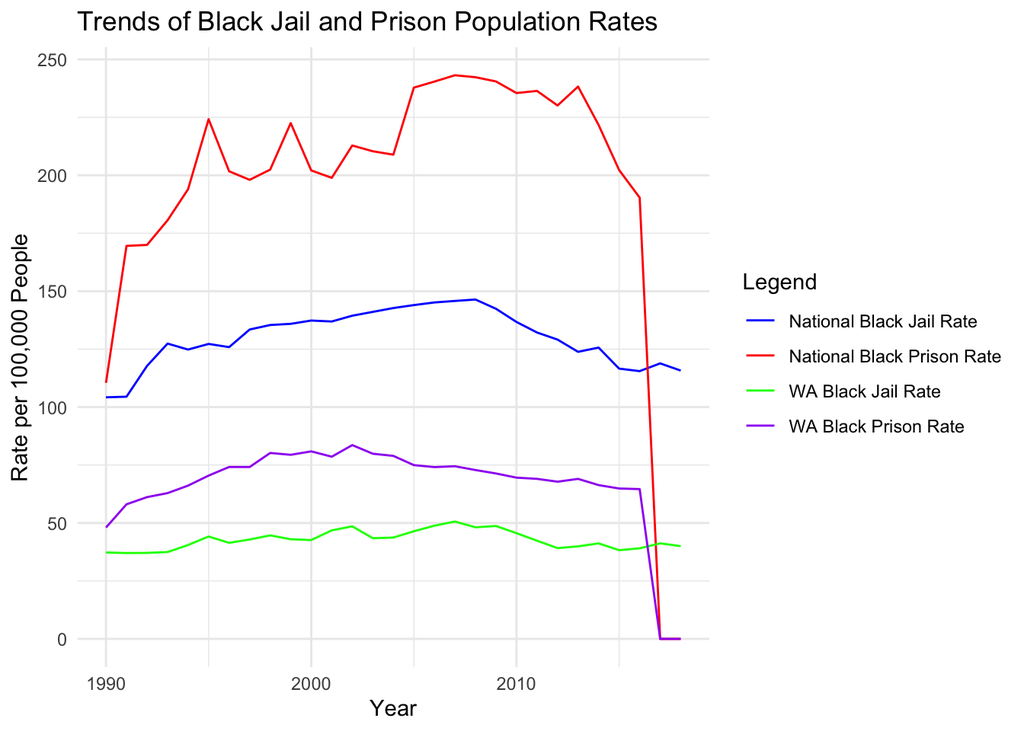

### Variable Comparison Chart

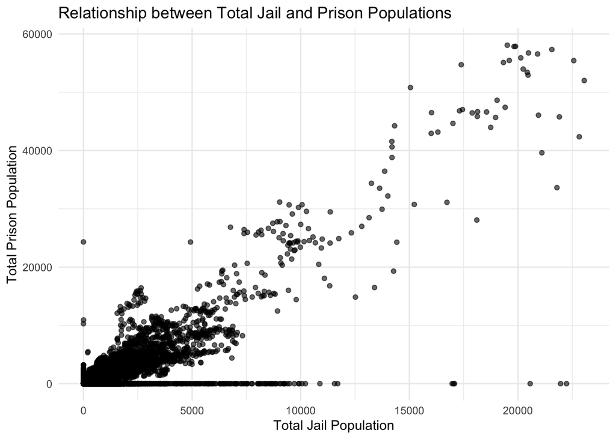

Two different continuous variables in the chart illustrates the relationship between the total jail population and the total prison population across different counties. This chart was included to investigate whether there is a correlation between the sizes of jail and prison populations. By examining this relationship, we can understand how these two forms of incarceration are related at the county level. From the chart, we observe a positive correlation, indicating that counties with larger jail populations also tend to have larger prison populations. This suggests that broader criminal justice policies and practices might influence both forms of incarceration similarly. However, it’s important to note that due to data limitations, some counties report zero jail and prison populations, likely because of incomplete or missing data. These gaps highlight the need for more comprehensive data collection to better understand the full scope of incarceration trends across the United States.

### Map

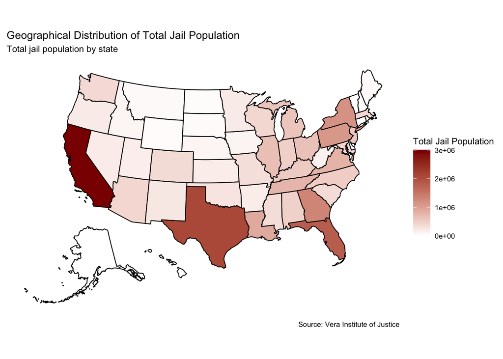

The map visualizes the total jail population by state across the United States. This chart is included to show the geographical distribution of incarceration, highlighting regions with higher jail populations. From the map, we observe that certain states, particularly in the eastern, southern, and western United States, have higher concentrations of jail populations, and the central and northern reign have lower concentrations of jail populations. This pattern indicates regional disparities in incarceration rates, which could be influenced by various factors, including local laws, crime rates, and socio-economic conditions. The color scale helps to easily identify states with higher jail populations, the darker color represents the higher concentrations of jail populations in that state which emphasizing areas where criminal justice interventions may be more heavily concentrated. Same issues as other two charts, some counties report zero jail and prison populations and make the map visualization not complete and comprehensive.